# Assignment07: Machine Learning

Author

Benjamin Reese

# Exercise 01

## Runing Code to Create Dataset

```r
## Loading Packages
library(tidyverse)
library(lubridate)
library(tidymodels)

# use this url to download the data directly into R
df <- read_csv("https://data.cityofnewyork.us/api/views/43nn-pn8j/rows.csv")

# clean names with janitor
sampled_df <- df %>%
  janitor::clean_names()

# create an inspection year variable
sampled_df <- sampled_df %>%
  mutate(inspection_date = mdy(inspection_date)) %>%
  mutate(inspection_year = year(inspection_date))

# get most-recent inspection
sampled_df <- sampled_df %>%
  group_by(camis) %>%
  filter(inspection_date == max(inspection_date)) %>%
  ungroup()

# subset the data
sampled_df <- sampled_df %>%
  select(camis, boro, zipcode, cuisine_description, inspection_date,
         action, violation_code, violation_description, grade,
         inspection_type, latitude, longitude, council_district,
         census_tract, inspection_year, critical_flag) %>%
  filter(complete.cases(.)) %>%
  filter(inspection_year >= 2017) %>%
  filter(grade %in% c("A", "B", "C"))

# create the binary target variable
sampled_df <- sampled_df %>%
  mutate(grade = if_else(grade == "A", "A", "Not A")) %>%
  mutate(grade = as.factor(grade))

# create extra predictors
sampled_df <- sampled_df %>%
  group_by(boro, zipcode, cuisine_description, inspection_date,
           action, violation_code, violation_description, grade,
           inspection_type, latitude, longitude, council_district,
           census_tract, inspection_year)  %>%
  mutate(vermin = str_detect(violation_description, pattern = "mice|rats|vermin|roaches")) %>%
  summarize(violations = n(),
            vermin_types = sum(vermin),
            critical_flags = sum(critical_flag == "Y")) %>%
  ungroup()

# write the data
write_csv(sampled_df, "restaurant_grades.csv")
```

## 1.

In this exercise, I split `sampled_df`, the restaurant data, into training and testing datasets, create a recipe, and estimate a decision tree model.

### a. Setting the Seed and Splitting the Dataset

```r
## Setting Seed
set.seed(20201020)

## Splitting the Sample
split <- initial_split(sampled_df, prop = 0.8)

## Training and Testing
restaurant_train <- training(split)
restaurant_test <- testing(split)
```

### b. Creating the Recipe

```r
## Creating the Recipe
restaurant_rec <-
  recipe(grade ~ ., data = restaurant_train) %>%
  themis::step_downsample(grade)
```

### c. Code for the Decision Tree

```r
## Creating the CART Model
cart_mod <-
  decision_tree() %>%
  set_engine(engine = "rpart") %>%
  set_mode(mode = "classification")

## Workflow
cart_wf <- workflow() %>%
  add_recipe(restaurant_rec) %>%
  add_model(cart_mod)

## Estimating the Model
cart_fit <- cart_wf %>%
  fit(data = restaurant_train)
```

## 2.

The code below evaluates the model by generating a confusion matrix and calculates precision and sensitivity. A written description of the quality of the model is also included.

### Creating predictions tibble

```r
## Selecting the Predictions
predictions <- bind_cols(
  restaurant_test,
  predict(object = cart_fit, new_data = restaurant_test),
  predict(object = cart_fit, new_data = restaurant_test, type = "prob")
) %>%
  mutate(color=as.factor(grade))

## The Predictions
select(predictions, grade, starts_with(".pred"))
```

```
# A tibble: 7,062 × 4
   grade .pred_class .pred_A `.pred_Not A`
   <fct> <fct>         <dbl>         <dbl>
 1 A     A             0.997       0.00274
 2 A     A             0.997       0.00274
 3 A     A             0.997       0.00274
 4 A     A             0.997       0.00274
 5 A     Not A         0.145       0.855
 6 A     A             0.997       0.00274
 7 A     A             0.997       0.00274
 8 A     A             0.997       0.00274
 9 A     A             0.997       0.00274
10 A     A             0.997       0.00274
# … with 7,052 more rows
```

### a. Confusion Matrix

```r
## Confusion matrix
conf_mat(data = predictions, truth = grade, estimate = .pred_class)
```

```
          Truth
Prediction    A Not A
     A     5017    13
     Not A 1296   736
```

### b. Calculating Precision & Recall

```r
## Precision
precision(data = predictions, truth = grade, estimate = .pred_class)
```

```
# A tibble: 1 × 3
  .metric   .estimator .estimate
  <chr>     <chr>          <dbl>
1 precision binary         0.997
```

```r
## Recall/Sensitivity
recall(data = predictions, truth = grade, estimate = .pred_class)
```

```
# A tibble: 1 × 3
  .metric .estimator .estimate
  <chr>   <chr>          <dbl>
1 recall  binary         0.795
```

## 3.

Using a *KNN*, or K-nearest neighbors, algorithm instead of the decision tree algorithm may improve the quality of the model. Instead of probabilistically dividing the data into two sets, based on predictors, as the decision tree model does, a *KNN* algorithm stores all available cases and classifies new cases by taking a majority vote of its *k* closest neighbors. This majority vote may prove more accurate than the binary dividing of the decision tree model.

## 4. Plot for Variable Importance

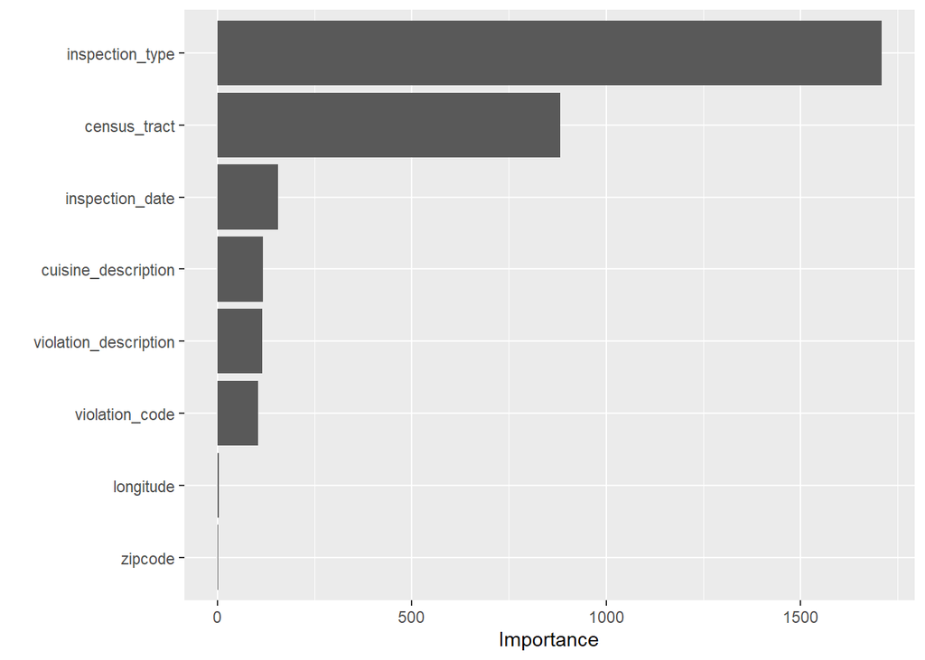

```r
library(vip)

cart_fit %>%
  extract_fit_parsnip() %>%
  vip(num_features = 10)
```

Variable, or feature, importance in decision tree models is calculated by finding the decrease in the Gini impurity - the quality of the split - weighted by the probability of reaching a node. Node probability is the proportion of samples that reach a node out of the total samples. The most important variables in a decision tree model are the variables associated with the most Gini impurity being eliminated - highest quality split - at each branch of the decision tree. In other words, the variable with the highest value of the decrease in impurity, weighted by the probability of the sample making it to a node, is the most important feature.

In the model above, the most important feature is the inspection type. Location, defined by the Census tract the restaurant is located in is the second most important variable. These two are followed by a series of variables related to the types of violations associated with a restaurant, the type of cuisine, and the date of the inspection. The most important feature, inspection type, is a categorical variable largely divided between initial and re-inspections. It is unsurprising that the most important predictor of a rating is the type of inspection because the rating is a direct result of an inspection, and the exact circumstances of an inspection surely dictate the ensuing ratings. It is also possible that restaurants fix violations and receive A ratings on subsequent visits and re-inspections, meaning re-inspection will predict A ratings.

## 5.

Restaurants that receive low ratings will want to correct their violations and try to raise their grade, but this requires an initial inspection. If restaurants correct after a rating, then the focus should be on casting a large net and reaching as many restaurants as possible, even foregoing continued visits at established businesses, in order to encourage restaurants to improve their health safety conditions. Also, location is one of the most important predictors of grade as well, so spending time inspecting restaurants in locations that are associated with low health inspection ratings will be an optimal use of health department resources.

# Exercise 2

## Running Code From Assignment

```r
Chicago_modeling <- Chicago %>%
slice(1:5678)

Chicago_implementation <- Chicago %>%
slice(5679:5698) %>%
select(-ridership)
```

## 1. Converting Date into Useable Variable

```r
## Loading Lubridate
library(lubridate)

## Converting Dates
Chicago_modeling <- Chicago_modeling %>%
  mutate(weekday = wday(date, label = TRUE),
         month = month(date, label = TRUE),
         yearday = yday(date)
  ) %>%
  janitor::clean_names() ## cleaning names
```

## 2. Setting up the testing enviroment

### a. Setting the Seed and Splitting Modeling Data into Training & Testing

```r
## Setting seed
set.seed(20211101)

## Splitting
split <- initial_split(data = Chicago_modeling)

## Training and Testing
chicago_train <- training(x = split)
chicago_test <- testing(x = split)
```

### b. Exploratory Data Analysis

```r
## Counting Daily Ridership
chicago_train %>%
  group_by(weekday) %>%
  summarise(avg_daily_ridership = mean(ridership))
```

```
# A tibble: 7 × 2
  weekday avg_daily_ridership
  <ord>                 <dbl>
1 Sun                    3.81
2 Mon                   16.6
3 Tue                   17.7
4 Wed                   17.8
5 Thu                   17.6
6 Fri                   17.0
7 Sat                    4.96
```

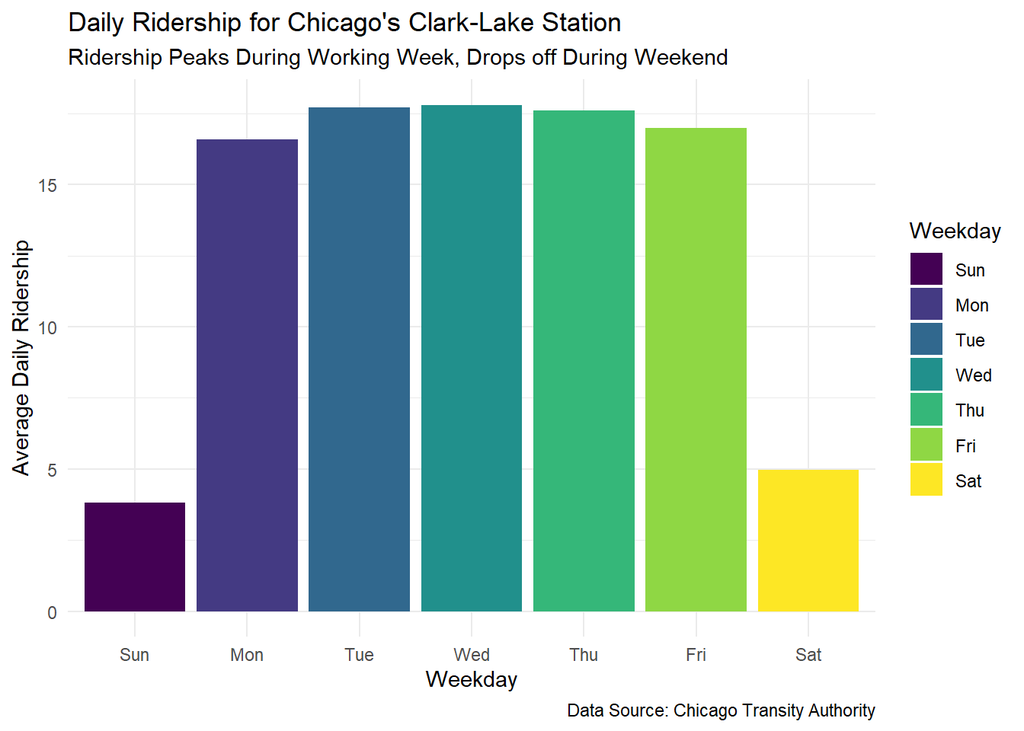

```r
## Daily Average Ridership Plot
chicago_train %>%
  group_by(weekday) %>%
  summarise(avg_daily_ridership = mean(ridership)) %>%
  ggplot(aes(x=weekday, y=avg_daily_ridership, fill=weekday)) +
  geom_col() +
  theme_minimal() +
  labs(title = "Daily Ridership for Chicago's Clark-Lake Station",
       x = "Weekday", y = "Average Daily Ridership", fill="Weekday",
       subtitle = "Ridership Peaks During Working Week, Drops off During Weekend",
       caption = "Data Source: Chicago Transity Authority")
```

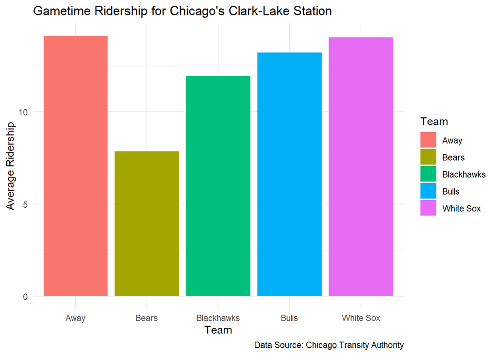

```r
## Ridership During Games Plot
chicago_train %>%
  mutate(game = case_when(
    blackhawks_home == 1 ~ "Blackhawks",
    bulls_home == 1 ~ "Bulls",
    bears_home == 1 ~ "Bears",
    white_sox_home == 1 ~ "White Sox",
    cubs_home == 1 ~ "Cubs",
    blackhawks_home == 0 ~ "Away",
    bulls_home == 0 ~ "Away",
    bears_home == 0 ~ "Away",
    white_sox_home == 0 ~ "Away",
    cubs_home == 0 ~ "Away",
  )) %>%
  group_by(game) %>%
  summarise(avg_gametime_ridership = mean(ridership)) %>%
  ggplot(aes(x=game, y=avg_gametime_ridership, fill=game)) +
  geom_col() +
  theme_minimal() +
  labs(title = "Gametime Ridership for Chicago's Clark-Lake Station",
       x = "Team", y = "Average Ridership", fill="Team",
       caption = "Data Source: Chicago Transity Authority")
```

```r
## Ridership During Bears Games
chicago_train %>%
  mutate(game = case_when(
    blackhawks_home == 1 ~ "Blackhawks",
    bulls_home == 1 ~ "Bulls",
    bears_home == 1 ~ "Bears",
    white_sox_home == 1 ~ "White Sox",
    cubs_home == 1 ~ "Cubs",
    blackhawks_home == 0 ~ "Away",
    bulls_home == 0 ~ "Away",
    bears_home == 0 ~ "Away",
    white_sox_home == 0 ~ "Away",
    cubs_home == 0 ~ "Away",
  )) %>%
  filter(weekday=="Sun") %>%
  group_by(bears_home) %>%
  summarise(avg_gametime_ridership = mean(ridership))
```

```
# A tibble: 2 × 2
  bears_home avg_gametime_ridership
       <dbl>                  <dbl>
1          0                   3.83
2          1                   3.67
```

```r
## Ridership During Inclement Weather
chicago_train %>%
  mutate(weather = case_when(
    weather_rain > 0 ~ "Rain",
    weather_snow > 0 ~ "Snow",
    weather_cloud > 0 ~ "Cloud",
    weather_storm > 0 ~ "Storm",
    weather_rain == 0 ~ "Sunny",
    weather_snow == 0 ~ "Sunny",
    weather_cloud == 0 ~ "Sunny",
    weather_storm == 0 ~ "Sunny",
  )) %>%
  group_by(weather) %>%
  summarise(weather_ridership = mean(ridership))
```

```
# A tibble: 4 × 2
  weather weather_ridership
  <chr>               <dbl>
1 Cloud                13.7
2 Rain                 13.9
3 Snow                 12.4
4 Sunny                14.6
```

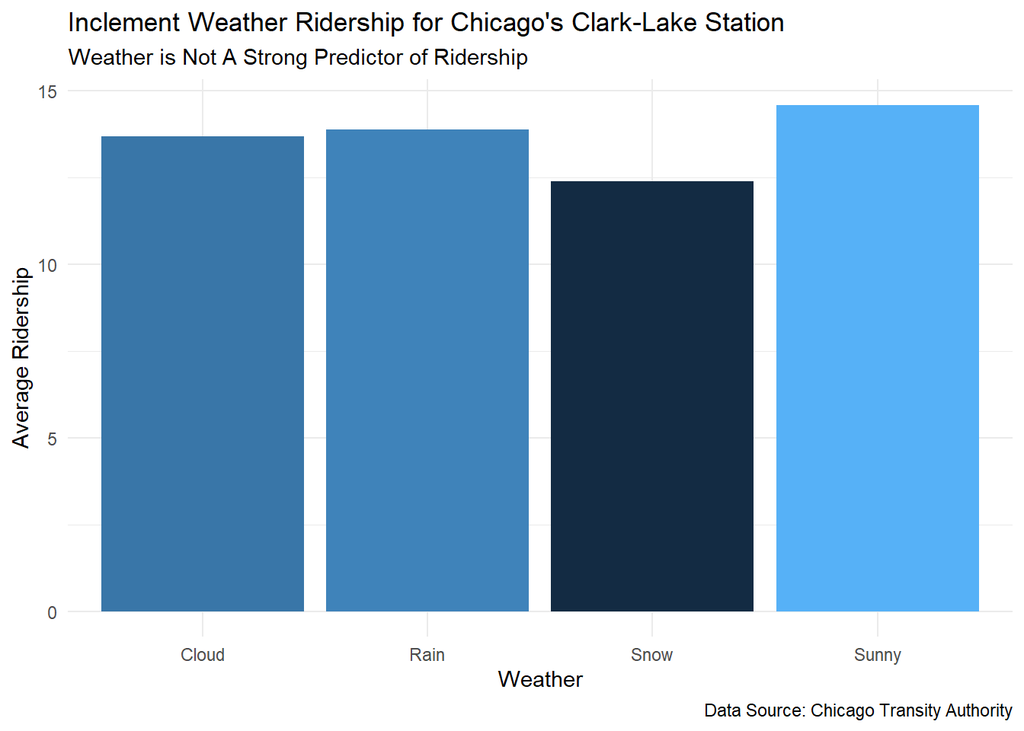

```r
chicago_train %>%
  mutate(weather = case_when(
    weather_rain > 0 ~ "Rain",
    weather_snow > 0 ~ "Snow",
    weather_cloud > 0 ~ "Cloud",
    weather_storm > 0 ~ "Storm",
    weather_rain == 0 ~ "Sunny",
    weather_snow == 0 ~ "Sunny",
    weather_cloud == 0 ~ "Sunny",
    weather_storm == 0 ~ "Sunny",
  )) %>%
  group_by(weather) %>%
  summarise(weather_ridership = mean(ridership)) %>%
  ggplot(aes(x=weather, y=weather_ridership, fill=weather_ridership)) +
  geom_col() +
  theme_minimal() +
  labs(title = "Inclement Weather Ridership for Chicago's Clark-Lake Station",
       x = "Weather", y = "Average Ridership",
       subtitle = "Weather is Not A Strong Predictor of Ridership",
       caption = "Data Source: Chicago Transity Authority") +
  theme(legend.position="none")
```

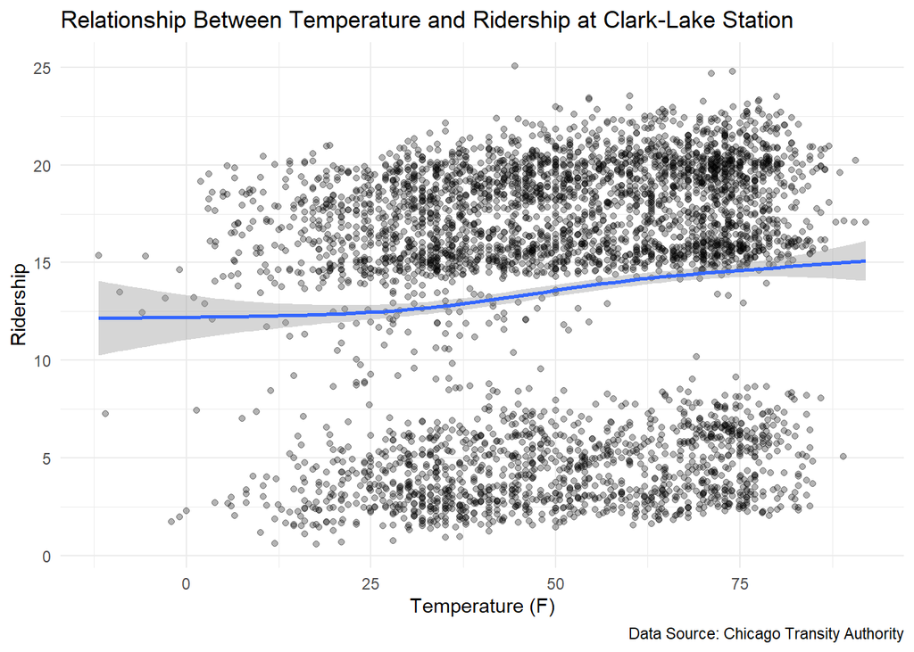

```r
## Relationship Between Weather and Ridership
chicago_train %>%
  ggplot(aes(x=temp, y=ridership)) +
  geom_point(alpha=.3) +
  geom_smooth() +
  theme_minimal() +
  labs(title = "Relationship Between Temperature and Ridership at Clark-Lake Station",
       x = "Temperature (F)", y = "Ridership", caption = "Data Source: Chicago Transity Authority")
```

My exploratory data analysis finds that the most important predictor of ridership is the day of the week with weekdays seeing a larger amount of ridership than weekends. Weather and temperature does not appear to have a strong effect, and neither does the occurrence of a professional sports game.

### c. Setting up v-fold cross validation

```r
## Setting up folds
folds <- vfold_cv(data = chicago_train, v = 10, repeats = 1)
```

## 3. Testing Different Approaches

### 1. Creating Recipe

```r
## Recipe
chicago_rec <-
  recipe(ridership ~ ., data = chicago_train) %>%
  step_dummy(all_nominal_predictors()) %>% ## Dummy encode categorical predictors
  step_normalize(all_numeric_predictors()) %>%   ## Center and scale all predictors
  step_nzv(all_predictors()) %>% ## Remove non-variance variables
  step_holiday(date) %>%
  step_rm(date)

## Baking Recipe
bake(prep(chicago_rec, training = chicago_train), new_data = chicago_train)
```

```
# A tibble: 4,258 × 64
    austin quincy_wells belmont archer…¹ oak_p…² western clark…³ clinton merch…⁴
     <dbl>        <dbl>   <dbl>    <dbl>   <dbl>   <dbl>   <dbl>   <dbl>   <dbl>
 1  0.0210      -0.0164   0.836    0.425  0.0489   0.407   0.331   0.687 -0.149
 2 -1.27        -1.40    -1.33    -1.26  -1.30    -1.28   -1.29   -1.36  -0.757
 3 -0.668       -1.36    -0.394   -0.507 -0.876   -0.679  -1.08   -0.744 -1.09
 4  1.08         0.756    1.20     0.900  0.950    0.752   0.853   1.06   0.818
 5  1.25         0.998    1.32     1.32   1.41     1.13    1.20    1.23   0.835
 6  0.172        0.437    0.169    0.182  0.221    0.208   0.162   0.252  0.396
 7  0.601        0.761    0.149    0.445  0.578    0.328   0.766   0.342  0.457
 8  0.306        0.456    0.256    0.737  0.484    0.621   0.662   0.382  0.555
 9  0.631        0.740    0.315    0.295  0.676    0.196   0.539   0.417  0.685
10  0.290        0.191    1.51     0.278  0.314    0.375   0.240   0.296 -0.0464
# … with 4,248 more rows, 55 more variables: irving_park <dbl>,
#   washington_wells <dbl>, harlem <dbl>, monroe <dbl>, polk <dbl>,
#   ashland <dbl>, kedzie <dbl>, addison <dbl>, jefferson_park <dbl>,
#   montrose <dbl>, california <dbl>, temp_min <dbl>, temp <dbl>,
#   temp_max <dbl>, temp_change <dbl>, dew <dbl>, humidity <dbl>,
#   pressure <dbl>, pressure_change <dbl>, wind <dbl>, wind_max <dbl>,
#   gust_max <dbl>, percip_max <dbl>, weather_cloud <dbl>, …
```

### 2. Defining Model Specifications

I specify a linear regression model, a KNN model with hyperparameter tuning, and a random forest model.

```r
## LM Model
lm_mod <- linear_reg() %>%
  set_engine("lm") %>%
  set_mode(mode="regression")

## KNN Model
knn_mod <- nearest_neighbor(neighbors = tune()) %>%
  set_engine(engine = "kknn") %>%
  set_mode(mode = "regression")


## Random Forest Model
rf_mod <- rand_forest() %>%
  set_engine(engine = "randomForest") %>%
  set_mode(mode = "regression")
```

### 3. Workflows For Each Model

```r
## LM Workflow
lm_wf <- workflow() %>%
  add_recipe(chicago_rec) %>%
  add_model(lm_mod)

## KNN Tuning Grid
knn_grid <- grid_regular(neighbors(range = c(1, 15)), levels = 8)

## KNN Workflow
knn_wf <- workflow() %>%
  add_model(spec = knn_mod) %>%
  add_recipe(recipe = chicago_rec)

## Random Forest Workflow
rf_wf <- workflow() %>%
  add_model(spec = rf_mod) %>%
  add_recipe(recipe = chicago_rec)
```

### 4. Fitting Models with v-fold Cross Validation

```r
## Fitting LM Model
lm_fit <- lm_wf %>%
  fit_resamples(resamples = folds, metrics = metric_set(mae, rmse))

## Fitting KNN Model
knn_fit <- knn_wf %>%
  tune_grid(resamples = folds,
            grid = knn_grid,
            control = control_grid(save_pred = TRUE),
            metrics = metric_set(rmse, mae))

## Fitting Random Forest Model
rf_fit <- rf_wf %>%
  fit_resamples(resamples = folds, metrics = metric_set(mae, rmse))
```

### 5. Calculating and Plotting RMSE and MAE for Each Model’s Resamples

```r
# All LM Error Metrics
lm_fit %>%
  collect_metrics(summarize=FALSE)
```

```
# A tibble: 20 × 5
   id     .metric .estimator .estimate .config
   <chr>  <chr>   <chr>          <dbl> <chr>
 1 Fold01 mae     standard        1.05 Preprocessor1_Model1
 2 Fold01 rmse    standard        1.85 Preprocessor1_Model1
 3 Fold02 mae     standard        1.14 Preprocessor1_Model1
 4 Fold02 rmse    standard        1.84 Preprocessor1_Model1
 5 Fold03 mae     standard        1.25 Preprocessor1_Model1
 6 Fold03 rmse    standard        2.38 Preprocessor1_Model1
 7 Fold04 mae     standard        1.36 Preprocessor1_Model1
 8 Fold04 rmse    standard        2.58 Preprocessor1_Model1
 9 Fold05 mae     standard        1.17 Preprocessor1_Model1
10 Fold05 rmse    standard        2.03 Preprocessor1_Model1
11 Fold06 mae     standard        1.27 Preprocessor1_Model1
12 Fold06 rmse    standard        2.30 Preprocessor1_Model1
13 Fold07 mae     standard        1.11 Preprocessor1_Model1
14 Fold07 rmse    standard        1.97 Preprocessor1_Model1
15 Fold08 mae     standard        1.24 Preprocessor1_Model1
16 Fold08 rmse    standard        2.21 Preprocessor1_Model1
17 Fold09 mae     standard        1.17 Preprocessor1_Model1
18 Fold09 rmse    standard        2.18 Preprocessor1_Model1
19 Fold10 mae     standard        1.14 Preprocessor1_Model1
20 Fold10 rmse    standard        1.96 Preprocessor1_Model1
```

```r
## Averaged LM Error Metrics
lm_fit %>%
  collect_metrics(summarize=TRUE) %>%
  filter(.metric == "rmse")
```

```
# A tibble: 1 × 6
  .metric .estimator  mean     n std_err .config
  <chr>   <chr>      <dbl> <int>   <dbl> <chr>
1 rmse    standard    2.13    10  0.0767 Preprocessor1_Model1
```

```r
# All KNN Error Metrics
knn_fit %>%
  collect_metrics(summarize = FALSE)
```

```
# A tibble: 160 × 6
   id     neighbors .metric .estimator .estimate .config
   <chr>      <int> <chr>   <chr>          <dbl> <chr>
 1 Fold01         1 rmse    standard        2.99 Preprocessor1_Model1
 2 Fold01         1 mae     standard        1.81 Preprocessor1_Model1
 3 Fold02         1 rmse    standard        3.06 Preprocessor1_Model1
 4 Fold02         1 mae     standard        1.82 Preprocessor1_Model1
 5 Fold03         1 rmse    standard        3.06 Preprocessor1_Model1
 6 Fold03         1 mae     standard        1.89 Preprocessor1_Model1
 7 Fold04         1 rmse    standard        3.39 Preprocessor1_Model1
 8 Fold04         1 mae     standard        2.08 Preprocessor1_Model1
 9 Fold05         1 rmse    standard        3.02 Preprocessor1_Model1
10 Fold05         1 mae     standard        1.90 Preprocessor1_Model1
# … with 150 more rows
```

```r
## Averaged KNN Error Metrics
knn_fit %>%
  collect_metrics(summarize=TRUE) %>%
  filter(.metric == "rmse") %>%
  summarize(avg_rmse = mean(mean))
```

```
# A tibble: 1 × 1
  avg_rmse
     <dbl>
1     2.60
```

```r
## All Random Forest Error Metrics
rf_fit %>%
  collect_metrics(summarize=FALSE)
```

```
# A tibble: 20 × 5
   id     .metric .estimator .estimate .config
   <chr>  <chr>   <chr>          <dbl> <chr>
 1 Fold01 mae     standard       0.787 Preprocessor1_Model1
 2 Fold01 rmse    standard       1.55  Preprocessor1_Model1
 3 Fold02 mae     standard       1.03  Preprocessor1_Model1
 4 Fold02 rmse    standard       1.92  Preprocessor1_Model1
 5 Fold03 mae     standard       1.00  Preprocessor1_Model1
 6 Fold03 rmse    standard       2.10  Preprocessor1_Model1
 7 Fold04 mae     standard       1.09  Preprocessor1_Model1
 8 Fold04 rmse    standard       2.38  Preprocessor1_Model1
 9 Fold05 mae     standard       0.941 Preprocessor1_Model1
10 Fold05 rmse    standard       1.86  Preprocessor1_Model1
11 Fold06 mae     standard       0.947 Preprocessor1_Model1
12 Fold06 rmse    standard       1.90  Preprocessor1_Model1
13 Fold07 mae     standard       0.813 Preprocessor1_Model1
14 Fold07 rmse    standard       1.69  Preprocessor1_Model1
15 Fold08 mae     standard       0.955 Preprocessor1_Model1
16 Fold08 rmse    standard       1.96  Preprocessor1_Model1
17 Fold09 mae     standard       0.886 Preprocessor1_Model1
18 Fold09 rmse    standard       1.89  Preprocessor1_Model1
19 Fold10 mae     standard       0.855 Preprocessor1_Model1
20 Fold10 rmse    standard       1.74  Preprocessor1_Model1
```

```r
## Averaged Random Forest Error Metrics
rf_fit %>%
  collect_metrics(summarize=TRUE) %>%
  filter(.metric == "rmse")
```

```
# A tibble: 1 × 6
  .metric .estimator  mean     n std_err .config
  <chr>   <chr>      <dbl> <int>   <dbl> <chr>
1 rmse    standard    1.90    10  0.0722 Preprocessor1_Model1
```

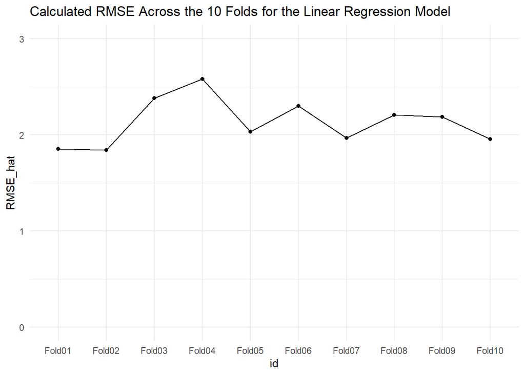

```r
## LM RMSE Plot
collect_metrics(lm_fit, summarize = FALSE) %>%
  filter(.metric == "rmse") %>%
  ggplot(aes(id, .estimate, group = .estimator)) +
  geom_line() +
  geom_point() +
  scale_y_continuous(limits=c(0,3)) +
  labs(title = "Calculated RMSE Across the 10 Folds for the Linear Regression Model",
       y = "RMSE_hat") +
  theme_minimal()
```

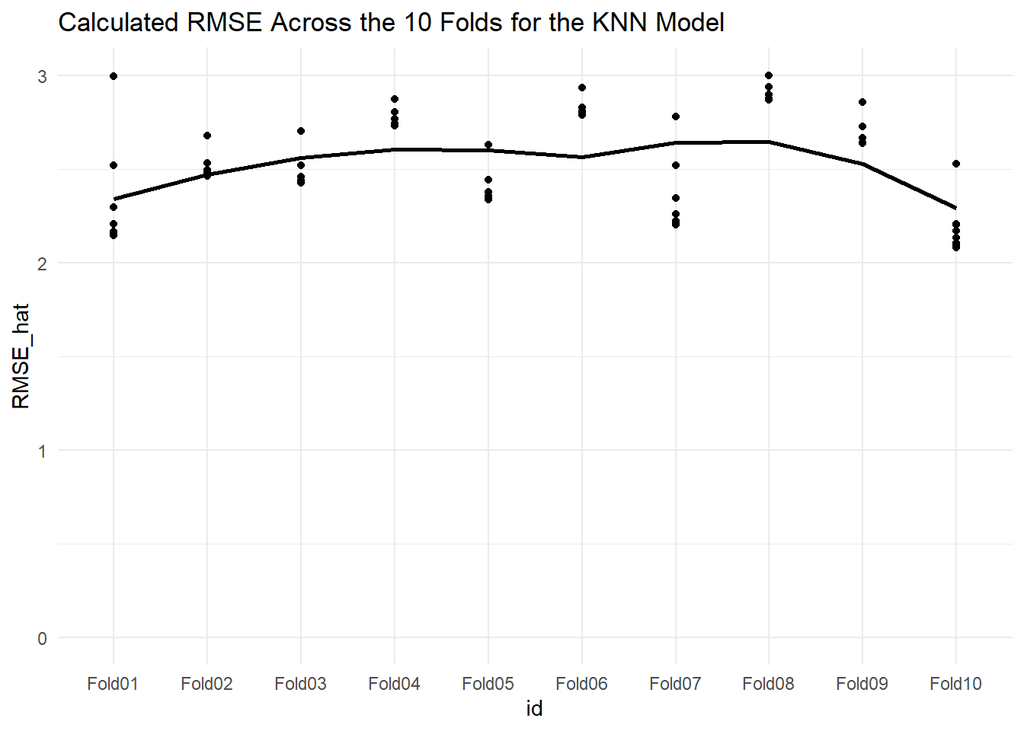

```r
## KNN RMSE Plot
collect_metrics(knn_fit, summarize = FALSE) %>%
  filter(.metric == "rmse") %>%
  ggplot(aes(id, .estimate, group = .estimator)) +
  geom_point() +
  geom_smooth(col="black", se=F) +
  scale_y_continuous(limits=c(0,3)) +
  labs(title = "Calculated RMSE Across the 10 Folds for the KNN Model",
       y = "RMSE_hat") +
  theme_minimal()
```

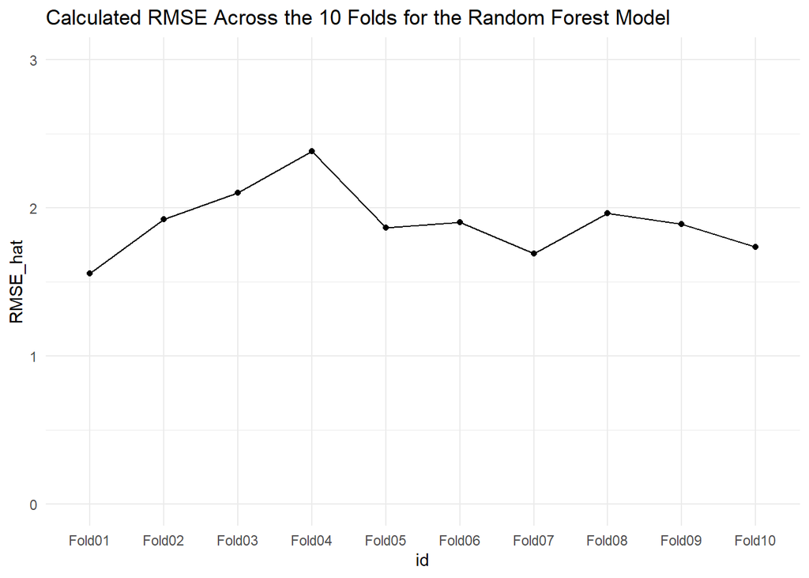

```r
## Random Forest RMSE Plot
collect_metrics(rf_fit, summarize = FALSE) %>%
  filter(.metric == "rmse") %>%
  ggplot(aes(id, .estimate, group = .estimator)) +
  geom_line() +
  geom_point() +
  scale_y_continuous(limits=c(0,3)) +
  labs(title = "Calculated RMSE Across the 10 Folds for the Random Forest Model",
       y = "RMSE_hat") +
  theme_minimal()
```

## 4. Calculating Out-of-Sample Error

The random forest model has both the lowest averaged mean absolute error and the lowest average root mean square error.

```r
## Selecting Best
rf_best <- rf_fit %>%
  select_best("rmse")

## Finalizing Workflow for Random Forest Model
rf_final <- rf_wf %>%
  tune::finalize_workflow(rf_best) %>%
  parsnip::fit(data = chicago_train)

## Using the Estimated Model Actual Values in the Training Data
predictions <-
  bind_cols(
    chicago_test,
    predict(object = rf_final, new_data = chicago_test)
)

rmse(data = predictions, truth = ridership, estimate = .pred)
```

```
# A tibble: 1 × 3
  .metric .estimator .estimate
  <chr>   <chr>          <dbl>
1 rmse    standard        1.97
```

## 5. Implementing the Final Model

```r
## Cleaning and Adding the weekday variables to the implementation data
Chicago_implementation <- Chicago_implementation %>%
  mutate(weekday = wday(date, label = TRUE),
         month = month(date, label = TRUE),
         yearday = yday(date)
  ) %>%
  janitor::clean_names()

## Predictions for Implementation Data
predict(object = rf_final, new_data = Chicago_implementation)
```

```
# A tibble: 20 × 1
   .pred
   <dbl>
 1 22.1
 2 21.4
 3 20.5
 4 21.9
 5  7.07
 6  6.57
 7 21.5
 8 21.8
 9 22.0
10 21.9
11 21.0
12  6.64
13  5.79
14 20.0
15 21.4
16 21.4
17 21.5
18 19.0
19  6.50
20  5.70
```

```r
## Calculating RMSE for the Implementation Data
rmse(data = predictions, truth = ridership, estimate = .pred)
```

```
# A tibble: 1 × 3
  .metric .estimator .estimate
  <chr>   <chr>          <dbl>
1 rmse    standard        1.97
```

## 6.

The model overall is somewhat accurate, predicting higher ridership values when there is actually higher ridership and low ridership when there is lower ridership. The size of our error metric, root mean square error, however may be troublesome for Chicago city officials. As the ridership variable is measured in thousands of riders, the root mean square error is nearly 2 thousand riders. When some days such as Saturdays and Sundays only have 6 thousand riders, then a policy choice based on having $\frac{1}{3}$ fewer or greater riders may become an issue. It is better, however, then no model.

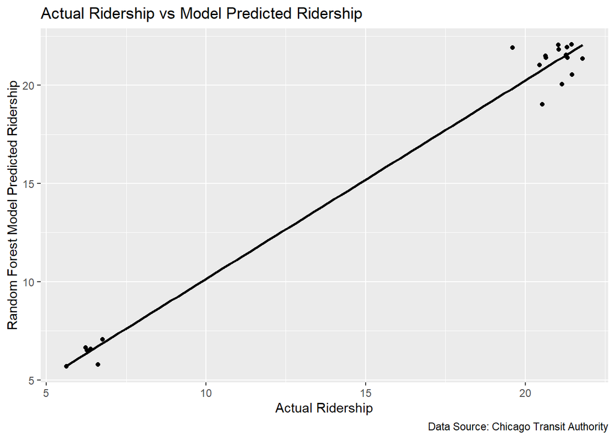

```r
## Saving Actual Values in Implementation Data
actual_values <- Chicago %>%
slice(5679:5698) %>%
select(ridership)

## Saving the Predicted Values
pred_values <- predict(object = rf_final, new_data = Chicago_implementation)

## Combining Columns
act_pred_values <- bind_cols(actual_values, pred_values)

## Visualizing Model Accuracy
act_pred_values %>%
  ggplot(aes(x=ridership, y=.pred)) +
  geom_point() +
  geom_smooth(method = "lm", se=F, col="black") +
  labs(title = "Actual Ridership vs Model Predicted Ridership",
       x = "Actual Ridership", y = "Random Forest Model Predicted Ridership",
       caption = "Data Source: Chicago Transit Authority")
```

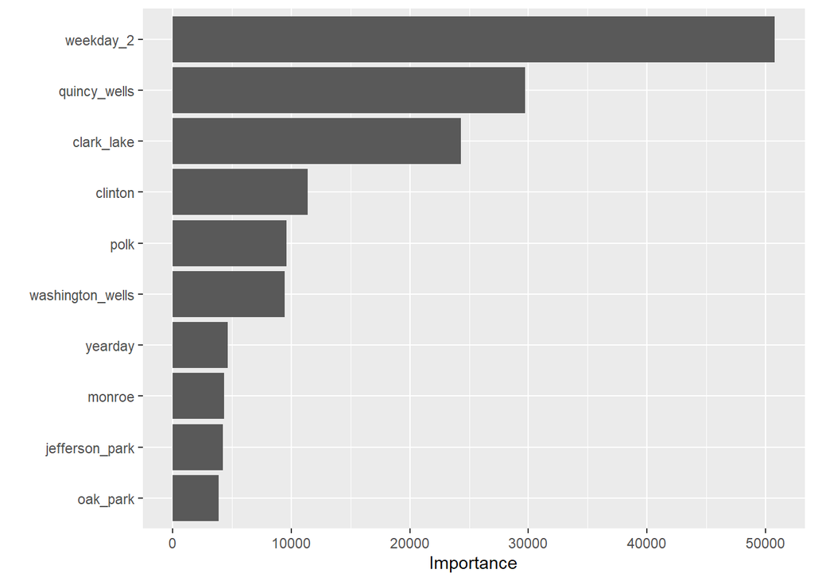

```r
## Showing the Important Variables
rf_final %>%
  extract_fit_parsnip() %>%
  vip(num_features = 10)
```